# Reddy_Vishruth_HW_08

## CMPINF 2100: Homework 08

## Assigned: Tuesday of Week 10 at 11:00PM

## DUE: Tuesday of Week 11 at 11:59PM

## Overview

This assignment involves two distinct applications. The first, reviews and wraps up the unit on clustering by reinforcing why standardization is an essential pre-processing operation. The second introduces you to the fundamentals of fitting linear models using `statsmodels`, interperting the coefficients, interpreting model behavior through predictions, and calculating performance metrics.

The clustering application corresponds to Problems 01 and 02. The linear model applications correspond to Problems 03 through 06.

**You must download the 3 data sets provided in the Canvas assignment page and save them to the appropriate directory on your computer.**

### Collaborators

None

## Problem 00

You will work with the NumPy, Pandas, matplotlib.pyplot, and Seaborn modules in this assignment. Several other modules will be imported later, but you must begin by importing "the big 4".

Import NumPy, Pandas, matplotlib.pyplot, and Seaborn using their commonly accepted aliases.

#### 00) - SOLUTION

```python
import numpy as np
import pandas as pd
import matplotlib.pyplot as plt

import seaborn as sns
```

## Problem 01

The first two questions are focused on cluster analysis. You will use KMeans to execute the clustering, but the concepts also apply to hierarchical clustering. You will **not** perform a detailed visual exploration of the data for this problem. You have demonstrated Exploratory Data Analysis (EDA) skills on previous assignments. This question is focused on a very specific concept.

### 1a)

Read in the `hw08_cluster.csv` CSV file and assign it to the `dfC` object.

Apply the `.info()` method to display useful information associated with the columns in the data set.

#### 1a) - SOLUTION

```python
dfC = pd.read_csv('hw08_cluster.csv')
dfC.head()
```

|  | x1 | x2 | x3 | x4 |
| --- | --- | --- | --- | --- |
| 0 | -0.320123 | 3.696071 | -9.202224 | 1200.217154 |
| 1 | -7.578649 | 6.216193 | 0.217607 | 1132.137445 |
| 2 | -7.174992 | 5.671260 | 3.735319 | 1167.780604 |
| 3 | -2.826721 | -4.692935 | 2.733356 | 836.563983 |
| 4 | 0.843429 | 3.123618 | -9.836258 | 1199.776498 |

```python
dfC.info()
```

```
<class 'pandas.core.frame.DataFrame'>
RangeIndex: 250 entries, 0 to 249
Data columns (total 4 columns):
 #   Column  Non-Null Count  Dtype
---  ------  --------------  -----
 0   x1      250 non-null    float64
 1   x2      250 non-null    float64
 2   x3      250 non-null    float64
 3   x4      250 non-null    float64
dtypes: float64(4)
memory usage: 7.9 KB
```

```python
dfC.nunique()
```

```
x1    250
x2    250
x3    250
x4    250
dtype: int64
```

```python
dfC.isna().sum()
```

```
x1    0
x2    0
x3    0
x4    0
dtype: int64
```

```python
dfC.describe()
```

|  | x1 | x2 | x3 | x4 |
| --- | --- | --- | --- | --- |
| count | 250.000000 | 250.000000 | 250.000000 | 250.000000 |
| mean | -2.542546 | -0.875056 | -1.742319 | 997.676171 |
| std | 4.612792 | 5.377312 | 5.038475 | 177.882827 |
| min | -10.512325 | -9.714752 | -10.753056 | 751.606388 |
| 25% | -6.684338 | -6.068994 | -6.310836 | 820.536042 |
| 50% | -3.171585 | -0.816839 | -0.953580 | 981.641205 |
| 75% | 1.565791 | 4.267897 | 2.942051 | 1177.098653 |
| max | 5.853405 | 6.743462 | 6.759024 | 1263.777451 |

### 1b)

Use the Seaborn wide-format plotting options to create a BOXPLOT to visually show the summary statistics associated with each column on the same axis within a single figure.

What is the primary conclusion that you make about the columns based on this BOXPLOT?

#### 1b) - SOLUTION

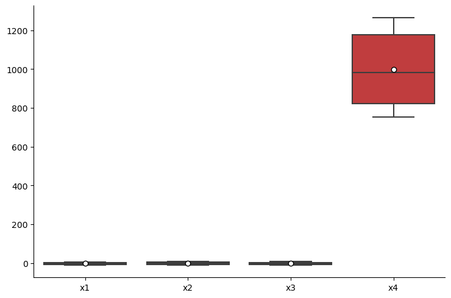

```python
sns.catplot(data = dfC, kind='box', aspect = 1.5,
            showmeans=True,
            meanprops={'marker': 'o', 'markerfacecolor': 'white', 'markeredgecolor': 'black'})

plt.show()
```

- The primary conclusion we can deduce from the above figure is that `x1, x2, x3` have an average value around `0`. Which means the values are either very close to 0 on the positive side or they do have negative and positive values close to 0 which we are not able to see through the plot.
- `x4` has an average value of `1000` with no negative values.

### 1c)

Visualize the marginal distributions and relationships between the columns using a pairs plot.

How many GROUPS or CLUSTERS do you expect to exist in the data based on the pairs plot?

#### 1c) - SOLUTION

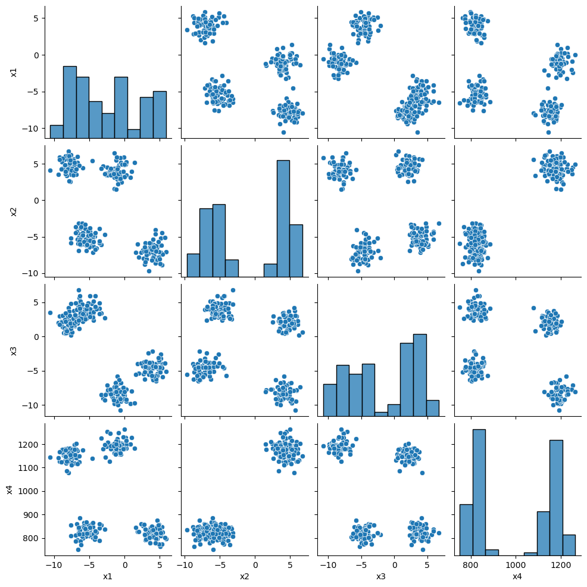

```python
sns.pairplot(data = dfC)

plt.show()
```

- I can see `4 clusters` in the pairs plot.

### 1d)

Import `KMeans()` from the `sklearn.cluster` module.

Sklearn functions typically prefer working with NumPy arrays than Pandas DataFrames.

You must also convert the `dfC` DataFrame into a NumPy array. Assign the converted NumPy array to the `XC` object.

#### 1d) - SOLUTION

```python
from sklearn.cluster import KMeans
```

```python
XC = dfC.to_numpy()
print(XC)
```

```
[[-3.20123357e-01  3.69607096e+00 -9.20222415e+00  1.20021715e+03]
 [-7.57864879e+00  6.21619303e+00  2.17607175e-01  1.13213744e+03]
 [-7.17499203e+00  5.67125968e+00  3.73531902e+00  1.16778060e+03]
 [-2.82672068e+00 -4.69293454e+00  2.73335625e+00  8.36563983e+02]
 [ 8.43428576e-01  3.12361790e+00 -9.83625754e+00  1.19977650e+03]
 [-7.46533287e-01  4.85934870e+00 -6.87280667e+00  1.18330274e+03]
 [ 4.60877962e+00 -7.02202758e+00 -5.49524356e+00  7.95956467e+02]
 [-8.47171056e+00  4.50019844e+00  3.03833425e+00  1.16941228e+03]
 [ 5.15460774e+00 -7.15203828e+00 -3.21815125e+00  8.09382922e+02]
 [ 5.27185827e+00 -8.86725666e+00 -3.94556911e+00  8.46540896e+02]
 [-1.73249144e-01  3.74660515e+00 -8.87797516e+00  1.18416720e+03]
 [ 4.59500247e+00 -7.89652708e+00 -5.75011679e+00  8.74133222e+02]
 [ 3.41344496e+00 -6.61715120e+00 -5.17735289e+00  7.97594162e+02]
 [-9.08430175e-01  4.49812713e+00 -8.83445447e+00  1.17624878e+03]
 [-6.57765657e+00 -5.97252432e+00  4.29777819e+00  7.51606388e+02]
 [-8.30980856e-01  3.75021205e+00 -9.27109808e+00  1.19445681e+03]
 [-4.58858175e+00 -6.04209112e+00  3.03431854e+00  8.20316929e+02]
 [ 4.46545668e+00 -7.83330892e+00 -6.30604843e+00  7.96704252e+02]
 [-1.47565908e+00  3.59548372e+00 -7.79931264e+00  1.19081963e+03]
 [-6.17828222e+00 -4.83065195e+00  4.36608116e+00  8.41574447e+02]
 [-7.42766111e+00  4.82574720e+00  2.50107127e+00  1.14003113e+03]
 [ 4.16681702e+00 -7.25595928e+00 -5.68245454e+00  8.27284441e+02]
 [-1.30909190e-01  5.90915307e+00 -7.89091963e+00  1.20153371e+03]
 [-1.04880065e+00  4.15532202e+00 -5.79216267e+00  1.22335388e+03]
 [-7.06638531e+00  4.08867155e+00  1.51254396e+00  1.18245234e+03]
 [-5.71879625e+00 -5.80530614e+00  3.62431170e+00  8.65811585e+02]
 [-7.91361817e+00  5.60917728e+00  4.17948878e+00  1.07863884e+03]
 [-6.80697954e+00  4.96200084e+00  2.18687906e+00  1.14238851e+03]
 [-5.90438341e+00  4.44421793e+00  2.21784191e+00  1.17352930e+03]
 [ 4.16035225e+00 -7.57662006e+00 -4.36154413e+00  8.43225813e+02]
 [ 4.46848874e+00 -8.07722458e+00 -6.53739326e+00  8.04587061e+02]
 [-7.44843293e+00  4.47728754e+00  1.88537271e+00  1.14800221e+03]
 [ 5.85340494e+00 -7.11125802e+00 -5.07511339e+00  7.96985053e+02]
 [ 4.81803337e+00 -6.29638681e+00 -4.76573467e+00  8.30924235e+02]
 [-9.96656430e-01  3.95648001e+00 -8.16124933e+00  1.18416079e+03]
 [-7.05356177e+00  4.21769738e+00  3.00759655e+00  1.11880510e+03]
 [-6.45369845e+00 -4.65536898e+00  5.67152911e+00  8.13904264e+02]
 [ 4.36962652e+00 -4.06267796e+00 -5.72860079e+00  8.09733582e+02]
 [ 4.38210808e+00 -8.64754634e+00 -4.35116578e+00  8.36344910e+02]
 [-6.49697850e+00 -5.09441745e+00  3.04061983e+00  8.39566574e+02]
```

[output cut: 195 more lines]

```
 [ 4.35812116e+00 -4.61961481e+00 -4.39128127e+00  7.77738782e+02]
 [-1.20053076e+00  1.49338907e+00 -8.05441615e+00  1.20017211e+03]
 [-1.88473386e-01  3.94278063e+00 -7.47950778e+00  1.17889916e+03]
 [-6.36514048e+00 -6.02952734e+00  4.10784555e+00  8.84643575e+02]
 [-7.06443316e+00  5.19820512e+00  1.88814020e+00  1.17785989e+03]
 [-8.37152088e+00  3.97763722e+00  3.42748388e+00  1.17566093e+03]
 [-5.56213014e+00 -3.35684942e+00  2.54873958e+00  8.40705188e+02]
 [-4.90588789e+00 -3.79280063e+00  2.89054640e+00  8.43907927e+02]
 [-6.97215678e+00  4.01728150e+00  3.13055620e+00  1.15338430e+03]
 [-6.84031927e+00  4.25927558e+00  2.17121320e+00  1.20253396e+03]
 [ 2.67654374e-01  5.20655194e+00 -9.22607550e+00  1.21646028e+03]
 [-6.13821289e+00 -3.61235569e+00  2.59563145e+00  7.70110697e+02]
 [-5.89188774e-01  2.92750279e+00 -9.11392778e+00  1.16223349e+03]
 [-6.46576927e+00 -6.89654023e+00  2.32078694e+00  8.45202585e+02]
 [-1.47891198e-02  4.94572714e+00 -8.08745205e+00  1.26377745e+03]]
```

### 1e)

You do not need to determine the optimal number of clusters using the "knee bend plot". Instead, you must execute the KMeans clustering with 4 clusters.

Cluster the observations within `dfC` into 4 clusters using the `XC` array. You must appropriately specify the remaining arguments to `KMeans()`. Assign the identified cluster labels to the `clusters_4C` object.

**Do NOT perform any preprocessing operations for this problem.**

#### 1e) - SOLUTION

```python
clusters_4c = KMeans(n_clusters=4, random_state=121, n_init=25, max_iter=500).fit_predict( XC )
clusters_4c
```

```
array([2, 0, 0, 3, 2, 2, 1, 0, 1, 3, 2, 3, 1, 2, 1, 2, 1, 1, 2, 3, 0, 3,
       2, 2, 2, 3, 0, 0, 2, 3, 1, 0, 1, 3, 2, 0, 1, 1, 3, 3, 3, 2, 1, 0,
       0, 3, 1, 0, 3, 3, 1, 1, 1, 1, 3, 1, 1, 1, 2, 0, 0, 2, 1, 0, 1, 2,
       3, 3, 0, 3, 0, 3, 1, 2, 2, 3, 2, 0, 3, 2, 2, 3, 1, 1, 0, 1, 1, 3,
       0, 0, 0, 2, 1, 2, 2, 2, 2, 2, 2, 2, 2, 0, 1, 2, 0, 3, 2, 2, 0, 2,
       2, 2, 2, 3, 0, 1, 1, 1, 1, 0, 0, 1, 1, 2, 1, 1, 0, 3, 3, 3, 2, 3,
       2, 0, 1, 1, 1, 2, 1, 1, 1, 0, 1, 1, 2, 1, 2, 3, 0, 2, 1, 1, 2, 3,
       3, 3, 1, 2, 2, 0, 0, 1, 3, 1, 1, 2, 1, 1, 1, 1, 1, 0, 3, 0, 0, 0,
       1, 3, 3, 0, 1, 3, 0, 3, 0, 2, 2, 2, 3, 2, 2, 2, 2, 0, 1, 2, 1, 2,
       1, 3, 2, 2, 2, 0, 0, 0, 2, 3, 2, 1, 1, 0, 1, 1, 0, 3, 3, 0, 0, 3,
       1, 1, 3, 2, 0, 0, 2, 1, 1, 1, 1, 1, 2, 0, 1, 1, 2, 2, 3, 2, 2, 3,
       3, 0, 2, 2, 1, 0, 3, 2], dtype=int32)
```

### 1f)

Create a copy of the `dfC` DataFrame named `dfC_copy`. Assign a new column to `dfC_copy` named `k4` which is equal to the identified cluster assignments. The `k4` column must be a category data type.

Display the COUNTS for each unique value of the `k4` column to the screen.

#### 1f) - SOLUTION

```python
dfC_copy = dfC.copy()
dfC_copy['k4'] = clusters_4c
dfC_copy['k4'] = dfC_copy['k4'].astype('category')
dfC_copy
```

|  | x1 | x2 | x3 | x4 | k4 |
| --- | --- | --- | --- | --- | --- |
| 0 | -0.320123 | 3.696071 | -9.202224 | 1200.217154 | 2 |
| 1 | -7.578649 | 6.216193 | 0.217607 | 1132.137445 | 0 |
| 2 | -7.174992 | 5.671260 | 3.735319 | 1167.780604 | 0 |
| 3 | -2.826721 | -4.692935 | 2.733356 | 836.563983 | 3 |
| 4 | 0.843429 | 3.123618 | -9.836258 | 1199.776498 | 2 |
| ... | ... | ... | ... | ... | ... |
| 245 | 0.267654 | 5.206552 | -9.226075 | 1216.460279 | 2 |
| 246 | -6.138213 | -3.612356 | 2.595631 | 770.110697 | 1 |
| 247 | -0.589189 | 2.927503 | -9.113928 | 1162.233488 | 0 |
| 248 | -6.465769 | -6.896540 | 2.320787 | 845.202585 | 3 |
| 249 | -0.014789 | 4.945727 | -8.087452 | 1263.777451 | 2 |

250 rows × 5 columns

```python
dfC_copy.k4.value_counts()
```

```
1    75
2    72
0    53
3    50
Name: k4, dtype: int64
```

### 1g)

Visualize the cluster analysis results using a pairs plot. Color the observations in the pairs plot based on the `k4` column.

**IMPORTANT**: You must remove the SAMPLE SIZE effect for the conditional KDE plots in the pairs plot.

#### 1g) - SOLUTION

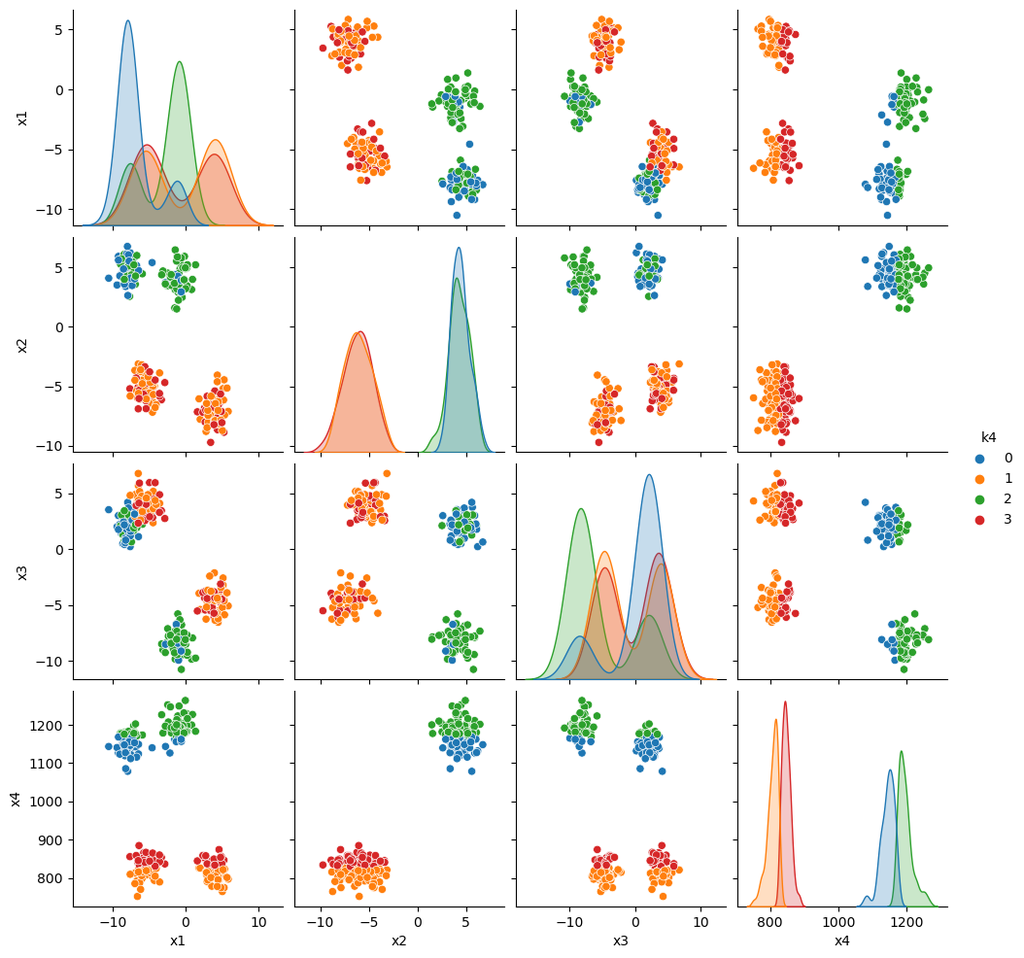

```python
sns.pairplot(data = dfC_copy, hue = 'k4',
             diag_kws={'common_norm': False})

plt.show()
```

### 1h)

Are the 4 identified clusters consistent with what you expected them to be?

#### 1h) - SOLUTION

Type your response in a markdown cell below.

- No, they are not consistent with what I had expected them to be. I assumed each pack of points to be a cluster but looking at the pairs plot above, I see that each pack of points have 2 sets of cluster points in them.

## Problem 02

The cluster analysis results in Problem 01 may not be satisfying. But, you were supposed to use the **RAW** data for the clustering. You did **NOT** preprocess the columns **before** executing KMeans clustering.

Let's see if the cluster analysis results change if the columns are **Standardized** before clustering!

### 2a)

Import `StandardScaler()` from the `sklearn.preprocessing` module.

#### 2a) - SOLUTION

```python
from sklearn.preprocessing import StandardScaler
```

### 2b)

Standardize the numeric columns in `dfC` using `StandardScaler()` and assign the transformed result to the `XC_stan` object.

Confirm the `XC_stan` object has the same dimensions as the `dfC` DataFrame.

#### 2b) - SOLUTION

```python
dfC_temp = dfC.select_dtypes('number').copy()
XC_stan = StandardScaler().fit_transform( dfC_temp )
XC_stan
```

```
array([[ 0.48276203,  0.85178195, -1.48355804,  1.14090431],
       [-1.09395907,  1.32138047,  0.38977238,  0.75741435],
       [-1.0062754 ,  1.21983781,  1.08934294,  0.95819067],
       [-0.0617294 , -0.71142188,  0.89008169, -0.90753776],
       [ 0.73551266,  0.74511129, -1.60964884,  1.13842211],
       [ 0.39013584,  1.06854665, -1.02030467,  1.04562615],
       [ 1.55343477, -1.14542412, -0.74634744, -1.13627809],
       [-1.28795293,  1.00162274,  0.95073294,  0.96738185],
       [ 1.67200137, -1.16965026, -0.29350002, -1.06064747],
       [ 1.69747092, -1.48926335, -0.43816227, -0.85133826],
       [ 0.51466653,  0.86119848, -1.41907435,  1.05049564],
       [ 1.55044205, -1.308378  , -0.79703431, -0.69591192],
       [ 1.29378019, -1.06997962, -0.68312824, -1.12705302],
       [ 0.35496806,  1.00123677, -1.41041935,  1.00589151],
       [-0.8765202 , -0.94986012,  1.2011997 , -1.3861001 ],
       [ 0.37179186,  0.86187058, -1.49725506,  1.10845656],
       [-0.44444674, -0.96282316,  0.94993433, -0.9990567 ],
       [ 1.52230168, -1.29659795, -0.90759294, -1.13206585],
       [ 0.2317527 ,  0.83303857, -1.20455976,  1.08796846],
       [-0.78976678, -0.73708409,  1.21478318, -0.87931405],
       [-1.06116102,  1.06228536,  0.84388697,  0.80187914],
       [ 1.45743018, -1.18901486, -0.78357826, -0.95980901],
       [ 0.52386376,  1.26416677, -1.22277772,  1.14832042],
       [ 0.32447632,  0.93735861, -0.80539601,  1.27123248],
       [-0.98268349,  0.92493899,  0.64729764,  1.0408359 ],
       [-0.6899557 , -0.91870075,  1.06726681, -0.74278733],
       [-1.16672224,  1.2082694 ,  1.17767538,  0.45605907],
       [-0.9263345 ,  1.08767481,  0.78140327,  0.81515812],
       [-0.73026956,  0.99119135,  0.78756088,  0.99057285],
       [ 1.45602588, -1.24876666, -0.5208876 , -0.87001197],
       [ 1.52296032, -1.3420491 , -0.9536007 , -1.08766234],
       [-1.06567315,  0.99735353,  0.72144243,  0.84677984],
       [ 1.82379643, -1.16205128, -0.66279577, -1.13048411],
       [ 1.59888957, -1.01020852, -0.60126934, -0.93930621],
       [ 0.33580326,  0.90030647, -1.27653843,  1.05045951],
       [-0.97989792,  0.94898161,  0.94462011,  0.68231383],
       [-0.84959361, -0.70442193,  1.4743988 , -1.03517895],
       [ 1.50148514, -0.59398013, -0.79275541, -1.05867222],
       [ 1.50419642, -1.44832262, -0.51882365, -0.90877179],
       [-0.85899504, -0.78623404,  0.95118748, -0.8906243 ],
```

[output cut: 195 more lines]

```
       [ 1.4989859 , -0.69775951, -0.52680146, -1.2388975 ],
       [ 0.291517  ,  0.44133512, -1.25529242,  1.14065056],
       [ 0.51135947,  0.89775373, -1.14095987,  1.02082102],
       [-0.83035675, -0.96048203,  1.16342763, -0.63670757],
       [-0.98225944,  1.13168902,  0.7219928 ,  1.01496683],
       [-1.26618939,  0.9042489 ,  1.02812348,  1.00258017],
       [-0.65592417, -0.46245633,  0.85336681, -0.88421054],
       [-0.51337304, -0.5436913 ,  0.92134224, -0.86616965],
       [-0.96221485,  0.9116362 ,  0.9690732 ,  0.87709695],
       [-0.93357667,  0.95672927,  0.77828779,  1.15395478],
       [ 0.61044107,  1.13324436, -1.48830138,  1.23240111],
       [-0.78106278, -0.51006726,  0.86269223, -1.28186616],
       [ 0.42431474,  0.70856728, -1.46599846,  0.92694402],
       [-0.85221567, -1.12204086,  0.80803366, -0.85887691],
       [ 0.54908775,  1.08464237, -1.2618623 ,  1.49893663]])
```

```python
XC_stan.shape == dfC.shape
```

```
True
```

### 2c)

Let's confirm the standardization accomplished what we wanted it to.

Create a BOXPLOT using the Seaborn wide-format plotting options. Create a DataFrame from the `XC_stan` object which has the same column names as the `dfC` DataFrame to support the creation of the figure.

How does this BOXPLOT compare to the BOXPLOT from 1b)?

#### 2c) - SOLUTION

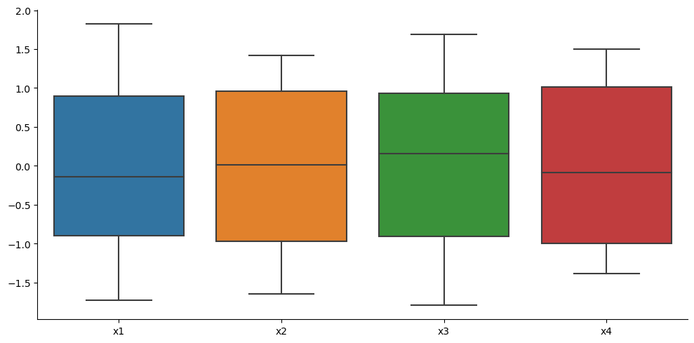

```python
sns.catplot(data = pd.DataFrame(XC_stan, columns=dfC_temp.columns), kind='box', aspect=2)

plt.show()
```

- After performing the standardization, I can see the range of values are more or less the same in all 4 variables as compared to the figure obtained in 1b which barely gave any information about x1, x2, x3.

### 2d)

You will now execute KMeans clustering again, but using the standardized columns contained in `XC_stan`. You will use 4 clusters again, just as you did in Problem 01.

Cluster the observations within `dfC` into 4 clusters using the standardized observations contained in the `XC_stan` array. You must appropriately specify the remaining arguments to `KMeans()`. Assign the identified cluster labels to the `clusters_4C_stan` object.

#### 2d) - SOLUTION

```python
clusters_4C_stan = KMeans(n_clusters=4, random_state=121, n_init=25, max_iter=500).fit_predict( XC_stan )
```

### 2e)

Assign a new column to `dfC_copy` named `k4_stan` which is equal to the identified cluster assignments contained in `clusters_4C_stan`. The `k4_stan` column must be a category data type.

Display the COUNTS for each unique value of the `k4_stan` column to the screen.

#### 2e) - SOLUTION

```python
dfC_copy['k4_stan'] = pd.Series( clusters_4C_stan, index=dfC_copy.index ).astype('category')
```

```python
dfC_copy.k4_stan.value_counts()
```

```
0    63
1    63
2    62
3    62
Name: k4_stan, dtype: int64
```

### 2f)

Visualize the cluster analysis results using a pairs plot. Color the observations in the pairs plot based on the `k4_stan` column.

**IMPORTANT**: You must remove the SAMPLE SIZE effect for the conditional KDE plots in the pairs plot.

#### 2f) - SOLUTION

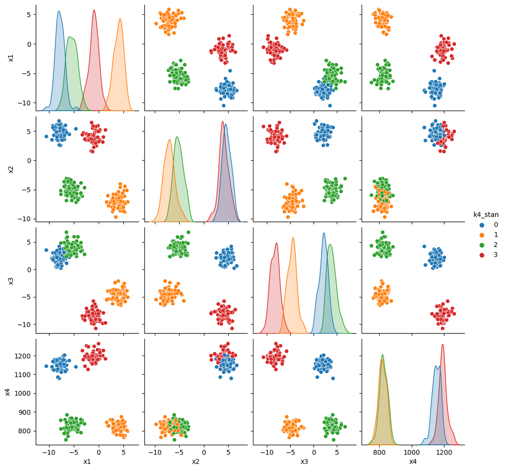

```python
sns.pairplot(data = dfC_copy, hue='k4_stan', diag_kws={'common_norm': False})

plt.show()
```

### 2g)

Are the 4 identified clusters consistent with what you expected them to be?

#### 2g) - SOLUTION

Type your response in a markdown cell below.

- Yes, the 4 identified clusters are consistent with what I had expected them to be.

### 2h)

Based on these questions, why do you think standardization is such an important operation to perform before clustering?

#### 2h) - SOLUTION

Type your response in a markdown cell below.

- Standardization brings all the variables to a common scale which inturn improves the cluster quality and hence, cluster visualization.

## Problem 03

Let's now shift focus and work on the fundamentals of fitting and interperting linear models for regression. You will repeat important actions on several data sets to gain experience working with linear models. Each of the following examples involves a single continuous input and continuous output just as the lecture recordings for this week. In each of the following examples the input variable is named `x` and the output variable is named `y`.

You will use the `statsmodels` formula interface to fit the models.

### 3a)

Import the `statsmodels.formula.api` as `smf`.

#### 3a) - SOLUTION

```python
import statsmodels.formula.api as smf
```

### 3b)

Read in the `hw08_lmA.csv` CSV file and assign it to the `dfA` object.

Apply the `.info()` method to display useful information associated with the columns in the data set.

#### 3b) - SOLUTION

```python
dfA = pd.read_csv("hw08_lmA.csv")
dfA.head()
```

|  | x | y |
| --- | --- | --- |
| 0 | -3.0 | -6.851932 |
| 1 | -2.7 | -7.823846 |
| 2 | -2.4 | -7.475097 |
| 3 | -2.1 | -9.705912 |
| 4 | -1.8 | -6.296723 |

```python
dfA.info()
```

```
<class 'pandas.core.frame.DataFrame'>
RangeIndex: 21 entries, 0 to 20
Data columns (total 2 columns):
 #   Column  Non-Null Count  Dtype
---  ------  --------------  -----
 0   x       21 non-null     float64
 1   y       21 non-null     float64
dtypes: float64(2)
memory usage: 464.0 bytes
```

### 3c)

You will NOT visually explore the variables in data for the regression problems in this assignment. Visual exploration is essential before fitting models, but this assignment is focused on introducing you to the important functions. That said, you must visualize the relationship between the OUTPUT and the INPUT.

Create a scatter plot to visualize the OUTPUT and INPUT relationship using Seaborn.

Do you think there is a negative or positive relationship between the two variables based on your visualization?

#### 3c) - SOLUTION

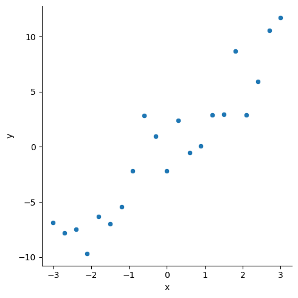

```python
sns.relplot(data = dfA, x='x', y='y')

plt.show()
```

- There is a positive relationship between the two variables.
- This is a graph with a positive linear relationship between the input-output variables.

### 3d)

Let's now fit your first linear model! You will fit the model for the classic or conventional "best fit line" between the OUTPUT and INPUT.

Fit a linear model using the `statsmodels` formula interface which uses a LINEAR RELATIONSHIP between the TREND and the INPUT.

Assign the fitted model to the `modA` object.

Print the `.summary()` method to the screen after fitting.

#### 3d) - SOLUTION

```python
modA = smf.ols( formula='y ~ x' , data=dfA ).fit()
```

```python
print(modA.summary())
```

```
                            OLS Regression Results
==============================================================================
Dep. Variable:                      y   R-squared:                       0.860
Model:                            OLS   Adj. R-squared:                  0.852
Method:                 Least Squares   F-statistic:                     116.5
Date:                Mon, 06 Nov 2023   Prob (F-statistic):           1.51e-09
Time:                        23:52:18   Log-Likelihood:                -47.180
No. Observations:                  21   AIC:                             98.36
Df Residuals:                      19   BIC:                             100.4
Df Model:                           1
Covariance Type:            nonrobust
==============================================================================
                 coef    std err          t      P>|t|      [0.025      0.975]
------------------------------------------------------------------------------
Intercept     -0.1726      0.525     -0.329      0.746      -1.271       0.926
x              3.1194      0.289     10.795      0.000       2.515       3.724
==============================================================================
Omnibus:                        1.719   Durbin-Watson:                   1.723
Prob(Omnibus):                  0.423   Jarque-Bera (JB):                1.215
Skew:                           0.345   Prob(JB):                        0.545
Kurtosis:                       2.045   Cond. No.                         1.82
==============================================================================

Notes:
[1] Standard Errors assume that the covariance matrix of the errors is correctly specified.
```

### 3e)

The `.summary()` method provides many useful and important details associated with the linear model. However, most of that information can be accessed and reporting using other attributes and methods associated with the `statsmodels` fitted model object.

Display the regression coefficient estimates using the appropriate attribute of `modA`.

Is the slope multiplying the input positive or negative?

#### 3e) - SOLUTION

```python
modA.params
```

```
Intercept   -0.172588
x            3.119407
dtype: float64
```

### 3f)

Display the regression coefficient standard errors using the appropriate attribute of `modA` to the screen.

Do you know if the coefficients are STATISTICALLY SIGNIFICANT based on the standard error values ALONE?

#### 3f - SOLUTION

```python
modA.bse
```

```
Intercept    0.524938
x            0.288969
dtype: float64
```

- No, it is not possible to know if the coefficients are statistically significant solely by standard error alone.

### 3g)

Display the p-value associated with the regression coefficients using the appropriate attribute of `modA` to the screen.

Is the INPUT considered to be STATISTICALLY SIGNIFICANT using COMMONLY accepted significance criteria?

#### 3g) - SOLUTION

```python
modA.pvalues
```

```
Intercept    7.459199e-01
x            1.513984e-09
dtype: float64
```

```python
modA.pvalues < 0.05
```

```
Intercept    False
x             True
dtype: bool
```

- The commonly accepted significance criteria is `pvalues < 0.05`. It is statistically significant as the input p-value is way less that 0.05.

### 3h)

Display the regression coefficient 95% confidence intervals using the appropriate method of `modA` to the screen.

The confidence interval bounds must be named `conf_lwr` and `conf_upr`.

How does the 95% confidence interval tell you if the INPUT is STATISTICALLY SIGNIFICANT using COMMONLY accepted significance criteria?

#### 3h) - SOLUTION

```python
modA.conf_int()
```

|  | 0 | 1 |
| --- | --- | --- |
| Intercept | -1.271296 | 0.926120 |
| x | 2.514589 | 3.724226 |

```python
modA.conf_int().\
rename(columns={0: 'conf_lwr', 1: 'conf_upr'})
```

|  | conf_lwr | conf_upr |
| --- | --- | --- |
| Intercept | -1.271296 | 0.926120 |
| x | 2.514589 | 3.724226 |

- The commonly accepted criteria says that the range should not include `0`. Since the input variable `x` doesn't include `0`, it is statistically significant.

## Problem 04

Now that you have examined the regression coefficients, it is time to interpret and visualize behavior via predictions.

However, as discussed in lecture it is not sufficient to predict the training set alone. Instead, you will predict a NEW data set that consists of input values NOT present in the training data. This NEW data will NOT contain the OUTPUT. The model will PREDICT the output using these NEW input values!

### 4a)

Create a NEW Pandas DataFrame, `dfA_viz`, that contains a single column named `x`. This column must consist of 101 evenly spaced values between the training set MINIMUM and training set MAXIMUM `x` values. Remember that the training set is contained in the `dfA` DataFrame.

Display the `.nunique()` method associated with `dfA_viz` to the screen to confirm it was created correctly.

#### 4a) - SOLUTION

```python
dfA_viz = pd.DataFrame({'x': np.linspace( dfA.x.min(), dfA.x.max(), num=101)})
dfA_viz
```

|  | x |
| --- | --- |
| 0 | -3.00 |
| 1 | -2.94 |
| 2 | -2.88 |
| 3 | -2.82 |
| 4 | -2.76 |
| ... | ... |
| 96 | 2.76 |
| 97 | 2.82 |
| 98 | 2.88 |
| 99 | 2.94 |
| 100 | 3.00 |

101 rows × 1 columns

```python
dfA_viz.nunique
```

```
<bound method DataFrame.nunique of         x
0   -3.00
1   -2.94
2   -2.88
3   -2.82
4   -2.76
..    ...
96   2.76
97   2.82
98   2.88
99   2.94
100  3.00

[101 rows x 1 columns]>
```

### 4b)

As discussed in lecture, linear model predictions require more than just producing a SINGLE number. To fully understand the model we must consider the predictive TREND, the UNCERTAINTY on the TREND, **and** the UNCERTAINTY on a single output observation!

You must use the appropriate method to "get" the predictions for `modA` on the NEW data set, `dfA_viz`. Assign the predictions to the `modA_pred_object` object.

**IMPORTANT**: The `modA_pred_object` is NOT a DataFrame. It is a `statsmodels` specific data type.

#### 4b) - SOLUTION

```python
modA_pred_object = modA.predict(dfA_viz)
modA_pred_object
```

```
0     -9.530810
1     -9.343646
2     -9.156481
3     -8.969317
4     -8.782152
         ...
96     8.436976
97     8.624141
98     8.811305
99     8.998470
100    9.185634
Length: 101, dtype: float64
```

### 4c)

The `modA_pred_object` is a "strange" data type. You need to apply one more method to correctly **SUMMARIZE** the predictions and return the predicted MEAN output (the TREND), the confidence interval bounds, and the prediction interval bounds.

Apply the appropriate method to SUMMARIZE the predictions for `modA` on the new data set, `dfA_viz`. Assign the prediction summaries to the `modA_pred_summary` object.

Display the head of `modA_pred_summary` object to the screen to confirm it is created correctly.

#### 4d) - SOLUTION

```python
modA_temp = modA.get_prediction( dfA_viz )
modA_pred_summary = modA_temp.summary_frame()
modA_pred_summary
```

|  | mean | mean_se | mean_ci_lower | mean_ci_upper | obs_ci_lower | obs_ci_upper |
| --- | --- | --- | --- | --- | --- | --- |
| 0 | -9.530810 | 1.013453 | -11.651991 | -7.409629 | -14.994302 | -4.067318 |
| 1 | -9.343646 | 0.998662 | -11.433870 | -7.253422 | -14.795193 | -3.892098 |
| 2 | -9.156481 | 0.983955 | -11.215922 | -7.097040 | -14.596300 | -3.716662 |
| 3 | -8.969317 | 0.969334 | -10.998157 | -6.940477 | -14.397624 | -3.541009 |
| 4 | -8.782152 | 0.954805 | -10.780582 | -6.783723 | -14.199167 | -3.365137 |
| ... | ... | ... | ... | ... | ... | ... |
| 96 | 8.436976 | 0.954805 | 6.438547 | 10.435406 | 3.019961 | 13.853992 |
| 97 | 8.624141 | 0.969334 | 6.595301 | 10.652981 | 3.195833 | 14.052449 |
| 98 | 8.811305 | 0.983955 | 6.751864 | 10.870746 | 3.371486 | 14.251124 |
| 99 | 8.998470 | 0.998662 | 6.908246 | 11.088694 | 3.546922 | 14.450017 |
| 100 | 9.185634 | 1.013453 | 7.064453 | 11.306815 | 3.722142 | 14.649126 |

101 rows × 6 columns

### 4e)

You now have everything necessary to visualize the predictions of the `modA` model on the NEW data, `dfA_viz`! You must visualize the predictive trend and BOTH types of uncertainty with respect to the input `x`.

You must visualize the predicted MEAN output (the trend) as a line. You must visualize the confidence interval as a grey ribbon. You must visualize the prediction interval as an orange ribbon. Include the training set as black markers for reference.

Create the figure using matplotlib methods associated with the matplotlib axis object. Label the x and y axis correctly.

#### 4e) - SOLUTION

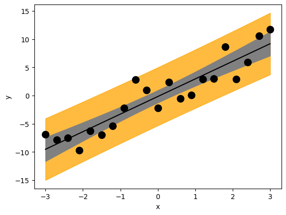

```python
fig, ax = plt.subplots()

# prediction interval - the uncertainty on a single measurement (observation)
ax.fill_between( dfA_viz.x,
                 modA_pred_summary.obs_ci_lower, modA_pred_summary.obs_ci_upper,
                 facecolor='orange', alpha=0.75, edgecolor='orange')

# confidence interval - the uncertainty on the mean output
ax.fill_between( dfA_viz.x,
                 modA_pred_summary.mean_ci_lower, modA_pred_summary.mean_ci_upper,
                 facecolor='grey', edgecolor='grey' )

# output mean - the predictive trend - the best fit line
ax.plot( dfA_viz.x, modA_pred_summary['mean'], color='k', linewidth=1.5)

# include the training data
ax.scatter( dfA.x, dfA.y, color='k', s=100 )

# set the labels
ax.set_xlabel('x')
ax.set_ylabel('y')

# show the plot
plt.show()
```

### 4f)

Is the predictive trend visualized in 4e) consistent with your conclusions about the input's statistical significance in Problem 03?

### 4g)

Are the training set observations mostly "contained" within the confidence interval or prediction interval in 4e)?

Why is that the case?

## Problem 05

Now that you have practiced working with linear models, let's try a more challenging situation.

### 5a)

Read in the `hw08_lmB.csv` CSV file and assign it to the `dfB` object.

Apply the `.info()` method to display useful information associated with the columns in the data set.

#### 5a) - SOLUTION

```python
dfB = pd.read_csv("hw08_lmB.csv")
dfB.head()
```

|  | x | y |
| --- | --- | --- |
| 0 | 0.233772 | -0.482308 |
| 1 | 0.267099 | -0.414248 |
| 2 | -2.413664 | 3.122495 |
| 3 | 1.103226 | 0.275180 |
| 4 | -0.603455 | -0.537027 |

```python
dfB.info()
```

```
<class 'pandas.core.frame.DataFrame'>
RangeIndex: 45 entries, 0 to 44
Data columns (total 2 columns):
 #   Column  Non-Null Count  Dtype
---  ------  --------------  -----
 0   x       45 non-null     float64
 1   y       45 non-null     float64
dtypes: float64(2)
memory usage: 848.0 bytes
```

### 5b)

As before, you will not perform a detailed visual exploration of the data. However, it is essential to examine the relationship between the OUTPUT and INPUT before fitting models.

Create a scatter plot to visualize the OUTPUT and INPUT relationship using Seaborn.

How would you describe the relationship between the two variables based on your visualization?

#### 5b) - SOLUTION

```python
sns.set_style('whitegrid')
```

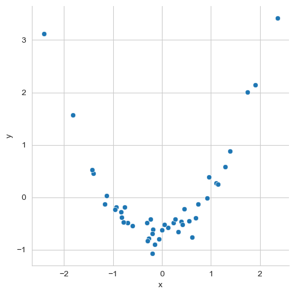

```python
sns.relplot(data = dfB, x='x', y='y')

plt.show()
```

### 5c)

You will fit MULTIPLE models in this problem. You will start with the SIMPLEST POSSIBLE LINEAR MODEL. You will start with an INTERCEPT-ONLY or CONSTANT AVERAGE model.

Fit a linear model using the `statsmodels` formula interface which uses a CONSTANT for the OUTPUT. Therefore, this model assumes there is NO relationship between the OUTPUT and the INPUT.

Assign the fitted model to the `modB_00` object.

Print the `.summary()` method to the screen after fitting.

#### 5c) - SOLUTION

```python
modB_00 = smf.ols(formula='y ~ 1', data=dfB).fit()
print(modB_00.summary())
```

```
                            OLS Regression Results
==============================================================================
Dep. Variable:                      y   R-squared:                      -0.000
Model:                            OLS   Adj. R-squared:                 -0.000
Method:                 Least Squares   F-statistic:                       nan
Date:                Mon, 06 Nov 2023   Prob (F-statistic):                nan
Time:                        23:52:19   Log-Likelihood:                -63.347
No. Observations:                  45   AIC:                             128.7
Df Residuals:                      44   BIC:                             130.5
Df Model:                           0
Covariance Type:            nonrobust
==============================================================================
                 coef    std err          t      P>|t|      [0.025      0.975]
------------------------------------------------------------------------------
Intercept  -2.896e-17      0.149  -1.94e-16      1.000      -0.300       0.300
==============================================================================
Omnibus:                       29.592   Durbin-Watson:                   1.955
Prob(Omnibus):                  0.000   Jarque-Bera (JB):               53.515
Skew:                           1.999   Prob(JB):                     2.39e-12
Kurtosis:                       6.545   Cond. No.                         1.00
==============================================================================

Notes:
[1] Standard Errors assume that the covariance matrix of the errors is correctly specified.
```

### 5d)

Let's fit another model BEFORE examining the coefficients in detail.

The next model is the classic or conventional "best fit line" which assumes a LINEAR RELATIONSHIP between the TREND and the INPUT.

Fit a linear model using the `statsmodels` formula interface which uses a LINEAR RELATIONSHIP between the TREND and the INPUT.

Assign the fitted model to the `modB_01` object.

Print the `.summary()` method to the screen after fitting.

#### 5d) - SOLUTION

```python
modB_01 = smf.ols(formula='y ~ x', data=dfB).fit()
print(modB_01.summary())
```

```
                            OLS Regression Results
==============================================================================
Dep. Variable:                      y   R-squared:                       0.035
Model:                            OLS   Adj. R-squared:                  0.013
Method:                 Least Squares   F-statistic:                     1.572
Date:                Mon, 06 Nov 2023   Prob (F-statistic):              0.217
Time:                        23:52:19   Log-Likelihood:                -62.539
No. Observations:                  45   AIC:                             129.1
Df Residuals:                      43   BIC:                             132.7
Df Model:                           1
Covariance Type:            nonrobust
==============================================================================
                 coef    std err          t      P>|t|      [0.025      0.975]
------------------------------------------------------------------------------
Intercept  -2.202e-17      0.148  -1.49e-16      1.000      -0.299       0.299
x              0.1878      0.150      1.254      0.217      -0.114       0.490
==============================================================================
Omnibus:                       31.178   Durbin-Watson:                   1.971
Prob(Omnibus):                  0.000   Jarque-Bera (JB):               61.060
Skew:                           2.044   Prob(JB):                     5.51e-14
Kurtosis:                       6.981   Cond. No.                         1.01
==============================================================================

Notes:
[1] Standard Errors assume that the covariance matrix of the errors is correctly specified.
```

### 5e)

Lastly, let's fit a model which includes a NON-LINEAR relationship between the TREND and the INPUT!

Fit a linear model using the `statsmodels` formula interface which includes the LINEAR **feature** and QUADRATIC **feature** between the TREND and the INPUT. This model is therefore a SECOND DEGREE polynomial between the TREND and the INPUT.

Assign the fitted model to the `modB_02` object.

Print the `.summary()` method to the screen after fitting.

#### 5e) - SOLUTION

```python
modB_02 = smf.ols(formula='y ~ x + np.power(x, 2)', data=dfB).fit()
print(modB_02.summary())
```

```
                            OLS Regression Results
==============================================================================
Dep. Variable:                      y   R-squared:                       0.975
Model:                            OLS   Adj. R-squared:                  0.974
Method:                 Least Squares   F-statistic:                     823.3
Date:                Mon, 06 Nov 2023   Prob (F-statistic):           2.04e-34
Time:                        23:52:19   Log-Likelihood:                 19.769
No. Observations:                  45   AIC:                            -33.54
Df Residuals:                      42   BIC:                            -28.12
Df Model:                           2
Covariance Type:            nonrobust
==================================================================================
                     coef    std err          t      P>|t|      [0.025      0.975]
----------------------------------------------------------------------------------
Intercept         -0.6953      0.030    -23.390      0.000      -0.755      -0.635
x                  0.1436      0.024      5.896      0.000       0.094       0.193
np.power(x, 2)     0.7111      0.018     39.839      0.000       0.675       0.747
==============================================================================
Omnibus:                        1.024   Durbin-Watson:                   1.754
Prob(Omnibus):                  0.599   Jarque-Bera (JB):                0.430
Skew:                          -0.208   Prob(JB):                        0.806
Kurtosis:                       3.238   Cond. No.                         2.38
==============================================================================

Notes:
[1] Standard Errors assume that the covariance matrix of the errors is correctly specified.
```

### 5f)

The coefficient summaries are reported within the `.summary()` table displayed for each of the three models. However, let's examine regression coefficients using a visualization which shows their estimates and confidence intervals. This visualization therefore allows us to determine which coefficients are statistically significant!

The lecture recordings demonstrated how to create the **COEFFICIENT PLOT** for a linear model. This plot uses error bars to show the 95% confidence interval around the estimate. The lecture recordings discussed two ways to create the figure. The first used an approximation to the 95% confidence interval and the second used the exact 95% confidence interval. You are allowed to use the **approximation** method for this assignment.

Create a function `my_coefplot()` which has 2 arguments. The zeroth argument, `mod`, is a `statsmodel` fitted model object. The first argument, `figsize_use`, allows the user to specify the figure size. A default `figsize_use` of `(10, 4)` should be used. The `my_coefplot()` function must create the error bars with matplotlib axis object methods. A vertical reference line must be located at 0. The axis labels must be labeled accordingly.

#### 5f) - SOLUTION

```python
def my_coefplot(mod, figsize_use=(10, 4)):
    fig, ax = plt.subplots(figsize=figsize_use)

    ax.errorbar( y=mod.params.index,
                 x=mod.params,
                 xerr = 2 * mod.bse,
                 fmt='o', color='k', ecolor='k', elinewidth=2, ms=10)

    ax.axvline(x=0, linestyle='--', linewidth=3.5, color='grey')

    ax.set_xlabel('coefficient value')

    plt.show()
```

### 5g)

Create the COEFFICIENT PLOTS for each of the models fit to the `dfB` data set: `modB_00`, `modB_01`, and `modB_02`.

Which features are statistically signficant for the models based on your visualizations?

#### 5g) - SOLUTION

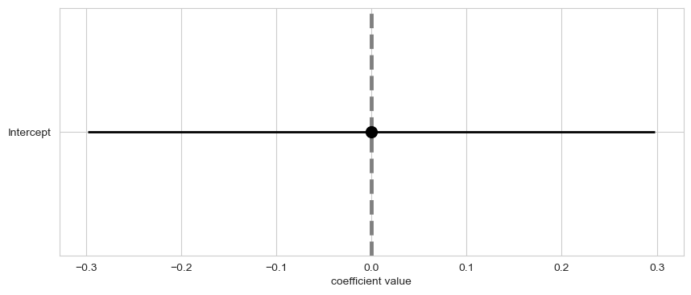

```python
my_coefplot( modB_00 )
```

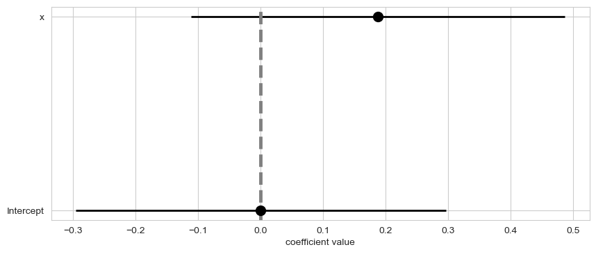

```python
my_coefplot( modB_01 )
```

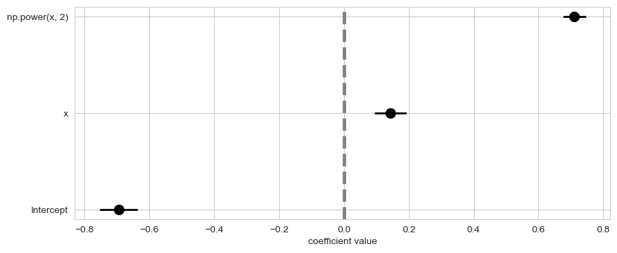

```python
my_coefplot( modB_02 )
```

- `Intercept, x and x^2` features of the modB_02 are statistically significant as they do not pass through the 0 coefficient value line.
- The other features in the other models are not significant as all the other features pass through the 0 mark.

## Problem 06

You fit 3 models to `dfB`. They each captured different types of RELATIONSHIPS between the TREND and the INPUT. The first, `modB_00` assumed NO TREND. The second, `modB_01`, assumed a LINEAR relationship. The third, `modB_02`, assumed a QUADRATIC relationship.

Let's now examine the training set PERFORMANCE and visually compare the behavior through predictions.

### 6a)

Display the R-squared performance metric to the screen for each of the 3 models.

Which model has the best R-squared value on the training set?

#### 6a) - SOLUTION

```python
modB_00.rsquared
```

```
-2.220446049250313e-16
```

```python
modB_01.rsquared
```

```
0.035270475898197984
```

```python
modB_02.rsquared
```

```
0.9751287319477502
```

- The model with the highest rsquared value is the best model. Therefore, Model 3 `modB_02` has the best rsquared value on the training dataset.

### 6b)

Calculate the RMSE for each of the 3 models and display each model's RMSE to the screen.

Which model has the best RMSE value on the training set?

#### 6b) - SOLUTION

```python
np.sqrt( (modB_00.resid ** 2).mean() )
```

```
0.9888264649460884
```

```python
np.sqrt( (modB_01.resid ** 2).mean() )
```

```
0.9712317386869485
```

```python
np.sqrt( (modB_02.resid ** 2).mean() )
```

```
0.1559441348901722
```

- The model with the lowest rmse value is the best model. Here, Model 3 `modB_02` has the best RMSE value on the training dataset.

### 6c)

Studying behavior via predictions requires creating a NEW data set, just as you did in Problem 04. However, this NEW data set will be specific to the `dfB` context.

Create a NEW Pandas DataFrame, `dfB_viz`, that contains a single column named `x`. This column must consist of 151 evenly spaced values between the training set MINIMUM and training set MAXIMUM `x` values. Remember that the training set is contained in the `dfB` DataFrame. Please note that 151 unique values are used in this problem to make sure things are different between your previous `dfA_viz` DataFrame. You cannot simply copy and paste!

Display the `.nunique()` method associated with `dfB_viz` to the screen to confirm it was created correctly.

#### 6c) - SOLUTION

```python
dfB_viz = pd.DataFrame({'x': np.linspace( dfB.x.min(), dfB.x.max(), num=151)})
dfB_viz
```

|  | x |
| --- | --- |
| 0 | -2.413664 |
| 1 | -2.381885 |
| 2 | -2.350107 |
| 3 | -2.318328 |
| 4 | -2.286549 |
| ... | ... |
| 146 | 2.226054 |
| 147 | 2.257833 |
| 148 | 2.289612 |
| 149 | 2.321390 |
| 150 | 2.353169 |

151 rows × 1 columns

```python
dfB_viz.nunique()
```

```
x    151
dtype: int64
```

### 6d)

You must now use the appropriate method to "get" the predictions for each of the 3 models on the NEW data set, `dfB_viz`. You must repeat the actions 3 times, once for each model.

Assign the predictions for `modB_00` to `modB_00_pred_object`. Assign the predictions for `modB_01` to `modB_01_pred_object`. Assign the predictions for `modB_02` to `modB_02_pred_object`.

#### 6d) - SOLUTION

```python
modB_00_pred_object = modB_00.predict( dfB_viz )
```

```python
modB_01_pred_object = modB_01.predict( dfB_viz )
```

```python
modB_02_pred_object = modB_02.predict( dfB_viz )
```

### 6e)

Apply the appropriate method to SUMMARIZE the predictions for each of the 3 models on the new data set, `dfB_viz`. You must repeat the actions 3 times, once for each model.

Assign the prediction summaries for `modB_00` to `modB_00_pred_summary`. Assign the prediction summaries for `modB_01` to `modB_01_pred_summary`. Assign the prediction summaries for `modB_02` to `modB_02_pred_summary`.

#### 6e) - SOLUTION

```python
modB_00_temp = modB_00.get_prediction( dfB_viz )
modB_00_pred_summary = modB_00_temp.summary_frame()
modB_00_pred_summary
```

|  | mean | mean_se | mean_ci_lower | mean_ci_upper | obs_ci_lower | obs_ci_upper |
| --- | --- | --- | --- | --- | --- | --- |
| 0 | -2.896106e-17 | 0.149071 | -0.300433 | 0.300433 | -2.037638 | 2.037638 |
| 1 | -2.896106e-17 | 0.149071 | -0.300433 | 0.300433 | -2.037638 | 2.037638 |
| 2 | -2.896106e-17 | 0.149071 | -0.300433 | 0.300433 | -2.037638 | 2.037638 |
| 3 | -2.896106e-17 | 0.149071 | -0.300433 | 0.300433 | -2.037638 | 2.037638 |
| 4 | -2.896106e-17 | 0.149071 | -0.300433 | 0.300433 | -2.037638 | 2.037638 |
| ... | ... | ... | ... | ... | ... | ... |
| 146 | -2.896106e-17 | 0.149071 | -0.300433 | 0.300433 | -2.037638 | 2.037638 |
| 147 | -2.896106e-17 | 0.149071 | -0.300433 | 0.300433 | -2.037638 | 2.037638 |
| 148 | -2.896106e-17 | 0.149071 | -0.300433 | 0.300433 | -2.037638 | 2.037638 |
| 149 | -2.896106e-17 | 0.149071 | -0.300433 | 0.300433 | -2.037638 | 2.037638 |
| 150 | -2.896106e-17 | 0.149071 | -0.300433 | 0.300433 | -2.037638 | 2.037638 |

151 rows × 6 columns

```python
modB_01_temp = modB_01.get_prediction( dfB_viz )
modB_01_pred_summary = modB_01_temp.summary_frame()
modB_01_pred_summary
```

|  | mean | mean_se | mean_ci_lower | mean_ci_upper | obs_ci_lower | obs_ci_upper |
| --- | --- | --- | --- | --- | --- | --- |
| 0 | -0.453297 | 0.390694 | -1.241206 | 0.334612 | -2.606352 | 1.699759 |
| 1 | -0.447328 | 0.386293 | -1.226363 | 0.331706 | -2.597152 | 1.702495 |
| 2 | -0.441360 | 0.381901 | -1.211538 | 0.328817 | -2.587990 | 1.705270 |
| 3 | -0.435392 | 0.377518 | -1.196731 | 0.325946 | -2.578867 | 1.708083 |
| 4 | -0.429424 | 0.373145 | -1.181942 | 0.323094 | -2.569781 | 1.710934 |
| ... | ... | ... | ... | ... | ... | ... |
| 146 | 0.418063 | 0.364846 | -0.317719 | 1.153844 | -1.716468 | 2.552593 |
| 147 | 0.424031 | 0.369201 | -0.320534 | 1.168595 | -1.713543 | 2.561605 |
| 148 | 0.429999 | 0.373566 | -0.323368 | 1.183366 | -1.710657 | 2.570655 |
| 149 | 0.435967 | 0.377940 | -0.326222 | 1.198157 | -1.707810 | 2.579744 |
| 150 | 0.441935 | 0.382324 | -0.329095 | 1.212966 | -1.705001 | 2.588872 |

151 rows × 6 columns

```python
modB_02_temp = modB_02.get_prediction( dfB_viz )
modB_02_pred_summary = modB_02_temp.summary_frame()
modB_02_pred_summary
```

|  | mean | mean_se | mean_ci_lower | mean_ci_upper | obs_ci_lower | obs_ci_upper |
| --- | --- | --- | --- | --- | --- | --- |
| 0 | 3.100615 | 0.109484 | 2.879666 | 3.321563 | 2.706999 | 3.494231 |
| 1 | 2.996814 | 0.106830 | 2.781223 | 3.212405 | 2.606180 | 3.387448 |
| 2 | 2.894449 | 0.104215 | 2.684135 | 3.104763 | 2.506703 | 3.282196 |
| 3 | 2.793521 | 0.101640 | 2.588403 | 2.998639 | 2.408568 | 3.178474 |
| 4 | 2.694029 | 0.099106 | 2.494025 | 2.894032 | 2.311776 | 3.076281 |
| ... | ... | ... | ... | ... | ... | ... |
| 146 | 3.147994 | 0.090604 | 2.965149 | 3.330840 | 2.774433 | 3.521555 |
| 147 | 3.253880 | 0.092970 | 3.066259 | 3.441501 | 2.877959 | 3.629802 |
| 148 | 3.361202 | 0.095378 | 3.168723 | 3.553682 | 2.982832 | 3.739573 |
| 149 | 3.469961 | 0.097826 | 3.272540 | 3.667382 | 3.089053 | 3.850869 |
| 150 | 3.580156 | 0.100316 | 3.377710 | 3.782601 | 3.196620 | 3.963691 |

151 rows × 6 columns

### 6f)

You now have everything in place to visualize the predictive behavior for each model on the NEW `dfB_viz` data set!

Let's start with the NO TREND or INTERCEPT-ONLY model, `modB_00`.

You must visualize the predictive trend and BOTH types of uncertainty with respect to the input `x`.

You must visualize the predicted MEAN output (the trend) as a line. You must visualize the confidence interval as a grey ribbon. You must visualize the prediction interval as an orange ribbon. Include the training set as black markers for reference.

Create the figure using matplotlib methods associated with the matplotlib axis object. Label the x and y axis correctly.

#### 6f) - SOLUTION

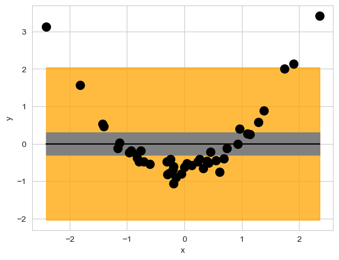

```python
fig, ax = plt.subplots()

# prediction interval - the uncertainty on a single measurement (observation)
ax.fill_between( dfB_viz.x,
                 modB_00_pred_summary.obs_ci_lower, modB_00_pred_summary.obs_ci_upper,
                 facecolor='orange', alpha=0.75, edgecolor='orange')

# confidence interval - the uncertainty on the mean output
ax.fill_between( dfB_viz.x,
                 modB_00_pred_summary.mean_ci_lower, modB_00_pred_summary.mean_ci_upper,
                 facecolor='grey', edgecolor='grey' )

# output mean - the predictive trend - the best fit line
ax.plot( dfB_viz.x, modB_00_pred_summary['mean'], color='k', linewidth=1.5)

# include the training data
ax.scatter( dfB.x, dfB.y, color='k', s=100 )

# set the labels
ax.set_xlabel('x')
ax.set_ylabel('y')

# show the plot
plt.show()
```

### 6g)

Let's now visualize the predictions for the LINEAR RELATIONSHIP model, `modB_01`.

You must visualize the predictive trend and BOTH types of uncertainty with respect to the input `x`.

You must visualize the predicted MEAN output (the trend) as a line. You must visualize the confidence interval as a grey ribbon. You must visualize the prediction interval as an orange ribbon. Include the training set as black markers for reference.

Create the figure using matplotlib methods associated with the matplotlib axis object. Label the x and y axis correctly.

#### 6g) - SOLUTION

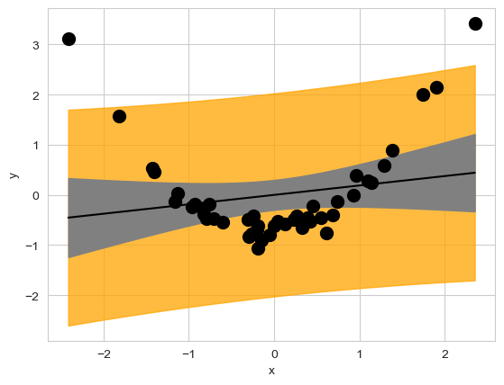

```python
fig, ax = plt.subplots()

# prediction interval - the uncertainty on a single measurement (observation)
ax.fill_between( dfB_viz.x,
                 modB_01_pred_summary.obs_ci_lower, modB_01_pred_summary.obs_ci_upper,
                 facecolor='orange', alpha=0.75, edgecolor='orange')

# confidence interval - the uncertainty on the mean output
ax.fill_between( dfB_viz.x,
                 modB_01_pred_summary.mean_ci_lower, modB_01_pred_summary.mean_ci_upper,
                 facecolor='grey', edgecolor='grey' )

# output mean - the predictive trend - the best fit line
ax.plot( dfB_viz.x, modB_01_pred_summary['mean'], color='k', linewidth=1.5)

# include the training data
ax.scatter( dfB.x, dfB.y, color='k', s=100 )

# set the labels
ax.set_xlabel('x')
ax.set_ylabel('y')

# show the plot
plt.show()
```

### 6h)

Finally, let's visualize the predictions for the QUADRATIC RELATIONSHIP model, `modB_02`.

You must visualize the predictive trend and BOTH types of uncertainty with respect to the input `x`.

You must visualize the predicted MEAN output (the trend) as a line. You must visualize the confidence interval as a grey ribbon. You must visualize the prediction interval as an orange ribbon. Include the training set as black markers for reference.

Create the figure using matplotlib methods associated with the matplotlib axis object. Label the x and y axis correctly.

#### 6h) - SOLUTION

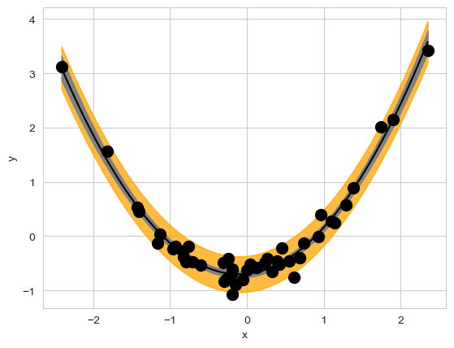

```python
fig, ax = plt.subplots()

# prediction interval - the uncertainty on a single measurement (observation)
ax.fill_between( dfB_viz.x,
                 modB_02_pred_summary.obs_ci_lower, modB_02_pred_summary.obs_ci_upper,
                 facecolor='orange', alpha=0.75, edgecolor='orange')

# confidence interval - the uncertainty on the mean output
ax.fill_between( dfB_viz.x,
                 modB_02_pred_summary.mean_ci_lower, modB_02_pred_summary.mean_ci_upper,
                 facecolor='grey', edgecolor='grey' )

# output mean - the predictive trend - the best fit line
ax.plot( dfB_viz.x, modB_02_pred_summary['mean'], color='k', linewidth=1.5)

# include the training data
ax.scatter( dfB.x, dfB.y, color='k', s=100 )

# set the labels
ax.set_xlabel('x')
ax.set_ylabel('y')

# show the plot
plt.show()
```

### 6i)

Which of the 3 models has predictions that appear the most consistent with the observed training set?

#### 6i) - SOLUTION

Type your response in a markdown cell below.

- The predictions for the QUADRATIC RELATIONSHIP model, `modB_02` appear to be the most consistent with the observed training dataset.

### 6j)

Are the predictions for the 3 types of models consistent with the R-squared and RMSE performance metrics you calculated in 6a) and 6b)? Essentially, are your prediction visualizations consistent with the model identified as the BEST according to R-squared and RMSE?

#### 6j) - SOLUTION

Type your response in a markdown cell below.

- Yes, the 3 models are consistent with the R-squared and RMSE performance metrics.
- Yes, the prediction visualizations are consistent with model 3 identified as the best model.